# Final Project

HYPOTHESIS: Revenue earned from streaming services has not fully compensated for the music industry’s decline in physical music sales, when adjusted for inflation.

This project analyzes recorded music data from the RIAA (1973-2025) to test whether streaming has fully compensated for the decline in physical music sales, when adjusted for inflation. Using CPI data as a baseline, I’ll compare inflation-adjusted revenue trends for physical and streaming, calculate year-over-year percentage changes, and measure the dollar gap between physical’s peak earnings and streaming’s current revenue.

Load necessary packages:

```r
library(tidyverse)
library(scales)
```

Loading the RIAA revenue dataset, which tracks recorded music sales by format from 1973-2025:

```r
music_revenue <- read_csv("/Users/zoebayewitz/Documents/GitHub/jour405_spring26/project/Recorded_Music_Revenue.csv")
```

Dataset loaded with four formats: Physical, Digital Downloads, Streaming, and Synchronization. Physical versus Streaming will be my focus.

The data is originally in wide format (each year is its own column), so it will be switched into long format so each row represents one format and one year. Data is cleaned so dollar signs and commas are gone, and they can be compared as whole numbers. from Derek:

```r
music_revenue_long <- music_revenue |>
  pivot_longer(
    cols = -Format2,
    names_to = "year",
    values_to = "revenue"
  ) |>
  mutate(
    year = as.integer(year),
    revenue = parse_number(revenue)
  ) |>
  rename(format = Format2)
```

Data now has three clean columns (format, year, revenue) that can be joined with the inflation data and filtered for analysis.

LOAD CPI INFLATION DATA:

```r
inflation <- read_csv("/Users/zoebayewitz/Documents/GitHub/jour405_spring26/project/Inflation_1973_2025.csv")
```

Loads CPI inflation data, which will be used to adjust music revenue figures to 2025 dollars. The dataset contains monthly CPI values from 1973-2025, with a pre-calculated annual average column that I will use instead of calculating my own averages (note: I ran code to find my own yearly averages, but they were nearly identical to the “Annual” column already given).

NARROWS INFLATION DATA DOWN TO COLUMNS NEEDED, AND RENAMED:

```r
inflation_annual <- inflation |>
 select(Year, Annual) |>
  rename (year = Year, cpi_annual = Annual)
```

Inflation data cleaned into a two-column dataset; to be used to adjust inflation when making direct yearly comparisons between revenue and format.

ADJUST DATA FOR 2025 INFLATION, TO USE AS BASELINE:

```r
base_cpi <- inflation_annual |>
  filter (year == 2025) |>
  pull(cpi_annual)
```

By using 2025 CPI as a baseline, every year’s revenue can be adjusted relative to a dollar’s value in 2025. Essentially, when we compare revenue from 1999 to revenue from 2025, we’re comparing in the same dollar terms rather than the dollar value of the respective year. AI assistance: https://claude.AI/share/b4e942a3-f913-419e-98a0-dc2b64ee56cd

JOIN REVENUE + INFLATION BY YEAR, THEN ADJUST REVENUE TO 2025 DOLLARS

```r
music_revenue_adjusted <- music_revenue_long |>
  left_join(inflation_annual, by = "year") |>
  mutate(adj_revenue = revenue * (base_cpi / cpi_annual))
```

Merges revenue and inflation data, then calculates revenue for every format and year, adjusted for inflation. Every format now has an adj_revenue column reflecting its value in 2025 dollars; this will allow me to make fair comparisons between physical sale peaks and recent streaming revenue.

FILTER TO PHYSICAL + STREAMING

```r
music_filtered <- music_revenue_adjusted |>
  filter(format %in% c("Physical", "Streaming"))

music_filtered_plot <- music_filtered |>
  filter(!(format == "Streaming" & adj_revenue == 0))
```

Filters data down to Physical and Streaming, which are the two formats I will be comparing. I opted to exclude Digital Downloads and Synchronization to make the hypothesis more direct. The second filtered version removes years where streaming had zero revenue to avoid skewing the regression chart.

DESCRIPTIVE STATISTICS OF ACTIVE YEARS TO GIVE GET SENSE OF SCALE DIFFERENCE:

```r
music_filtered|>
  filter(adj_revenue > 0) |>
  group_by(format) |>
  summarize(
    mean_revenue = mean(adj_revenue, na.rm = TRUE),
    median_revenue = median(adj_revenue, na.rm = TRUE),
    max_revenue = max(adj_revenue, na.rm = TRUE),
    min_revenue = min(adj_revenue, na.rm = TRUE)
  )
```

| format | mean_revenue | median_revenue | max_revenue | min_revenue |
| --- | --- | --- | --- | --- |
| Physical | 7700173894 | 8362990960 | 16010310686 | 847218661 |
| Streaming | 3973722080 | 2236718557 | 9558040272 | 11759697 |

INFLATION-ADJUSTED REVENUE FOR BOTH FORMATS, WITH REGRESSION LINE, TO SHOW GENERAL TRENDS (REGRESSION CHART)

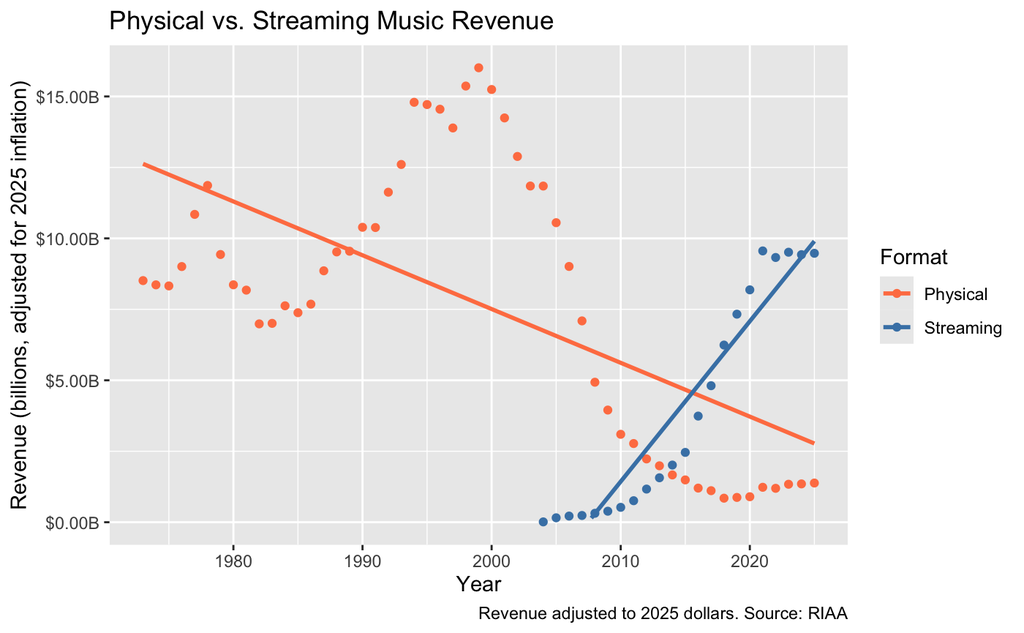

```r
ggplot(music_filtered_plot, aes(x = year, y = adj_revenue, color = format)) +
  geom_point() +
  geom_smooth(method = "lm", se = FALSE) +
  scale_color_manual (
    values = c("Physical" = "coral", "Streaming" = "steelblue"),
    name = "Format") +
  scale_y_continuous(
    labels = label_dollar(scale = 1e-9, suffix = "B"),
    limits = c(0, NA)) +
  labs(
    x = "Year",
    y = "Revenue (billions, adjusted for 2025 inflation)",
    caption = "Revenue adjusted to 2025 dollars. Source: RIAA",
    title = "Physical vs. Streaming Music Revenue"
  )
```

CALCULATE DOLLAR GAP BETWEEN PHYSICAL’S PEAK REVENUE AND STREAMING’S MOST RECENT REVENUE, IN 2025 DOLLARS:

```r
peak_physical <- music_filtered |>
  filter(format == "Physical") |>
  slice_max(adj_revenue, n = 1) |>
  select(year, adj_revenue)

latest_streaming <- music_filtered |>
  filter(format == "Streaming") |>
  slice_max(year, n = 1) |>
  select(year, adj_revenue)

gap <- peak_physical$adj_revenue - latest_streaming$adj_revenue

print(peak_physical)
```

| year | adj_revenue |
| --- | --- |
| 1999 | 16010310686 |

```r
print(latest_streaming)
```

| year | adj_revenue |
| --- | --- |
| 2025 | 9474510633 |

```r
print(gap)
```

```
[1] 6535800053
```

Physical sales peaked in 1999 at approximately $16b (in 2025 dollars). Streaming’s 2025 annual revenue came to about $9.47b, which is still $6.5 billion short of what physical sales earned at their peak. Based on this data, streaming has yet to close the revenue gap.

CALCULATE YEAR-BY-YEAR % CHANGE FOR BOTH FORMATS (ADJUSTED FOR INFLATION); SHOWS WHERE PHSYICAL DECLINED FASTER THAN STREAMING WAS GROWING:

```r
yearly_change <- music_filtered |>
  group_by(format) |>
  arrange(year) |>
  mutate(
    prev_revenue = lag(adj_revenue),
    pct_change = round((adj_revenue - prev_revenue) / prev_revenue * 100,2),
    pct_change = ifelse(is.nan(pct_change) | is.infinite(pct_change), NA, pct_change)
  )

yearly_change
```

| format | year | revenue | cpi_annual | adj_revenue | prev_revenue | pct_change |
| --- | --- | --- | --- | --- | --- | --- |
| Physical | 1973 | 1174013153 | 44.400 | 8512732354 | NA | NA |
| Streaming | 1973 | 0 | 44.400 | 0 | NA | NA |
| Physical | 1974 | 1280647364 | 49.300 | 8362990960 | 8512732354 | -1.76 |
| Streaming | 1974 | 0 | 49.300 | 0 | 0 | NA |
| Physical | 1975 | 1391301519 | 53.800 | 8325646560 | 8362990960 | -0.45 |
| Streaming | 1975 | 0 | 53.800 | 0 | 0 | NA |
| Physical | 1976 | 1592009621 | 56.900 | 9007668777 | 8325646560 | 8.19 |
| Streaming | 1976 | 0 | 56.900 | 0 | 0 | NA |
| Physical | 1977 | 2041419599 | 60.600 | 10845226897 | 9007668777 | 20.40 |
| Streaming | 1977 | 0 | 60.600 | 0 | 0 | NA |

[output cut: 96 more lines]

The table shows the most prominent declines in physical occurred between 2007-2010, dropping nearly 20% or more annually, while streaming’s dollar gains were too small to compensate those losses. AI assistance: https://claude.ai/share/2ca7e995-15ee-4d87-84d5-15815f11dbc2

VISUALIZES YEAR-BY-YEAR % CHANGE FOR BOTH FORMATS:

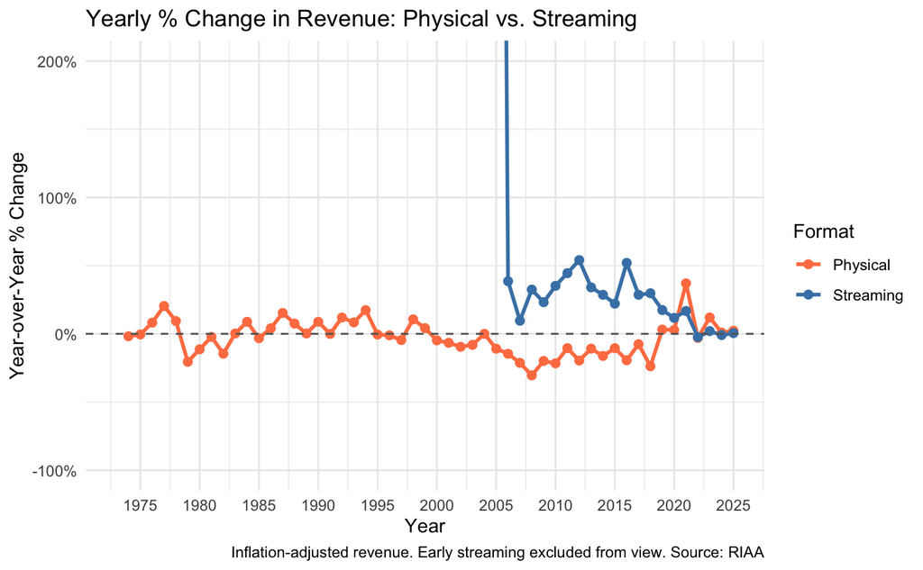

```r
ggplot(yearly_change, aes(x= year, y = pct_change, color = format)) +
  geom_line(linewidth = 1) +
  geom_point(size = 2) +
  geom_hline(yintercept = 0, linetype = "dashed", color = "gray40") +
  scale_color_manual(
    values = c("Physical" = "coral", "Streaming" = "steelblue"),
    name = "Format") +
    scale_x_continuous(breaks = scales::pretty_breaks(n = 10)) +
    scale_y_continuous(labels = scales::label_percent(scale = 1)) +
    coord_cartesian(ylim = c(-100, 200)) +
    labs (
      title = "Yearly % Change in Revenue: Physical vs. Streaming",
      x = "Year",
      y = "Year-over-Year % Change",
      caption = "Inflation-adjusted revenue. Early streaming excluded from view. Source: RIAA"
    )+
  theme_minimal()
```

This graph shows that physical sales experienced their sharpest declines between 2007 and 2010, dropping nearly 20% or more each year. During that window, streaming was growing rapidly in percentage terms, but was too small in dollar amounts to compensate for those losses. Streaming’s growth rate has also slowed significantly since 2020, while physical’s decline has stabilized; this suggests that the gap between the two is unlikely to close in the near future. Added colors for consistency across charts. Note: Inputted what I knew to do for ggplots, then asked AI for help with full thing. Asked it specifically about how to present this graph (zooming in on relevant years): https://claude.ai/share/78c16b04-638a-40d6-a6c2-0ca128aa5cff

TOTAL INDUSTRY RECOVERY: CALCULATING WHAT % OF PHYSICAL’S 1999 PEAK REVENUE HAS BEEN RECOVERED EACH YEAR BY STREAMING, IN 2025 DOLLARS

```r
peak_physical_revenue <- music_filtered |>
  filter (format == "Physical") |>
  slice_max(adj_revenue, n=1) |>
  pull(adj_revenue)

recovery <- music_filtered |>
  filter(format == "Streaming") |>
  filter(adj_revenue > 0) |>
  mutate(pct_recovered = (adj_revenue / peak_physical_revenue) * 100) |>
  select(year, adj_revenue, pct_recovered)

recovery
```

| year | adj_revenue | pct_recovered |
| --- | --- | --- |
| 2004 | 11759697 | 0.07345077 |
| 2005 | 156603096 | 0.97813902 |
| 2006 | 217024074 | 1.35552694 |
| 2007 | 237875912 | 1.48576699 |
| 2008 | 315060124 | 1.96785765 |
| 2009 | 388065739 | 2.42384890 |
| 2010 | 524720906 | 3.27739365 |
| 2011 | 758130900 | 4.73526663 |
| 2012 | 1167882499 | 7.29456487 |
| 2013 | 1565699744 | 9.77932143 |

[output cut: 12 more lines]

Streaming has steadily recovered a large portion of physical’s peak each year, but is still not close: by 2025, streaming has only recovered 59% of what physical earned at its peak.

GRAPH OF STREAMING’S YEARLY PROGRESS TOWARD PHYSICAL’S 1999 PEAK; CORAL LINE AT 100% REPRESENTS PHYSICAL’S 1999 PEAK, WHICIH STREAMING WOULD NEED TO REACH TO FULLY COMPENSATE FOR PHYSICAL’S DECLINE:

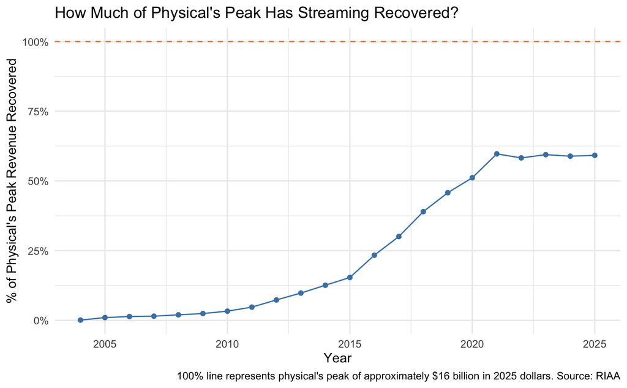

```r
ggplot(recovery, aes(x= year, y = pct_recovered)) +
  geom_line(color="steelblue") +
  geom_point(color="steelblue") +
  geom_hline(yintercept = 100, linetype = "dashed", color = "coral") +
  scale_y_continuous(labels = label_percent(scale = 1)) +
    labs (
      title = "How Much of Physical's Peak Has Streaming Recovered?",
      x = "Year",
      y = "% of Physical's Peak Revenue Recovered",
      caption = "100% line represents physical's peak of approximately $16 billion in 2025 dollars. Source: RIAA"
    ) +
  theme_minimal()
```

The graph shows streaming steadily increasing through the 2010’s but plateauing in the 2020s, with no signs of reaching 100% recovery anytime soon.

STORY PITCH

Headline: Streaming Has Recovered Less Than 60% of what Physical Sales Once Earned

Potential problems include only comparing physical and streaming (excluding digital downloads), which could change the overall industry’s recovery. Early 2000s streaming revenue is extremely small, which creates misleading percentage growth spikes that may not reflect real dollar recovery. RIAA data also does not report artist compensation.

I would interview RIAA representatives about the gap between physical and streaming revenue, and whether they think the industry has recovered. I would try contacting 1-2 independent music labels and 1-2 major music labels, and ask how the shift of physical to streaming has affected their earnings. I would also reach out to Spotify representatives to ask about their growth trajectories. Finally, I’d try finding economists/analysts who can speak on the economic/financial status of the music industry.